# Analyzing the horizontal orientation of the crustal stress adjacent to plate boundaries

Tobias Stephan

2023-08-06

## Some terms and definitions

Angular data

Directional data (0-360$^{\circ}$) e.g. dip direction, paleocurrent direction, …

Axial data (0-180$^{\circ}$) e.g. strike, trend, …

homogeneous or uniform stress field = all angles have similar trends, i.e. sampled from a uniform distribution with low dispersion

> Angles can be expressed either in radians or degrees $1 rad = 1^{\circ} * \frac{\pi}{180^{\circ}}$

## Problem 1: Circular statistics for angular data

- Angular data are periodical, linear data are not.
- Angular data are distributed along a circle $\theta \subset \mathbb{R}, 0 \leq \theta \leq 2\pi]$ – linear data are distributed along a line $x \subset \mathbb{R}, -\infty \leq x \leq \infty$
- requires different mathematics to describe the distribution (e.g. mean and variance):

```r
x <-  c(1, 359)

mean(x)
```

```
## [1] 180
```

```r
sd(x)
```

```
## [1] 253.1442
```

### The mean direction

#### Angles to Vectors

Using trigonometry functions:

$$\begin{align*}
x &= \cos{\theta} / r \\
y &= \sin{\theta} / r
\end{align*}$$
we get the rectangular coordinates of the vector in the circle of radius $r$ represented by the angle $\theta$. For simplification, $r = 1$.

#### Mean direction $\bar{\theta}$

Coordinates of resultant vector $R$:
$$\begin{align*}
x_R &= \sum_{i=1}^{n} \cos{\theta_i} \\
y_R &= \sum_{i=1}^{n} \sin{\theta_i}
\end{align*}$$

$n$ is the number of angles

Using trigonometry functions:
$$\tan{\bar{\theta}} = \frac{y_R}{x_R}$$

#### Variance

Variance is expressed by the length of the mean resultant vector $R$:

Using theorem of Pythagoras:
$$R =
\sqrt{x_R^2 + y_R^2}$$

Length of R depends on **variance** of $\theta_i$ and the number of angles $n$. Thus, we “normalize” $R$ by $n$:

$$\bar{R} = \frac{R}{n} =
\sqrt{\bar{x_R}^2 + \bar{y_R}^2}$$

$\bar{R}$ has length = 1, when all angles $\theta_i$ are equal, and length = 0 when, the angle are randomly distributed (along the circumference of the circle). Thus, the variance of the angles is:

$$\sigma^2 = 1 - \bar{R}$$

The standard deviation is:
$$\sigma = \sqrt{-2 \log{(1-\sigma^2)}} = \sqrt{-2 \log{\bar{R}}}$$

```r
circular_mean(x, axial = FALSE)
```

```
## [1] 360
```

```r
circular_sd(x, axial = FALSE)
```

```
## [1] 1.000025
```

#### Normal distribution

##### (Linear) normal distribution: $f(x | \mu, \sigma)$

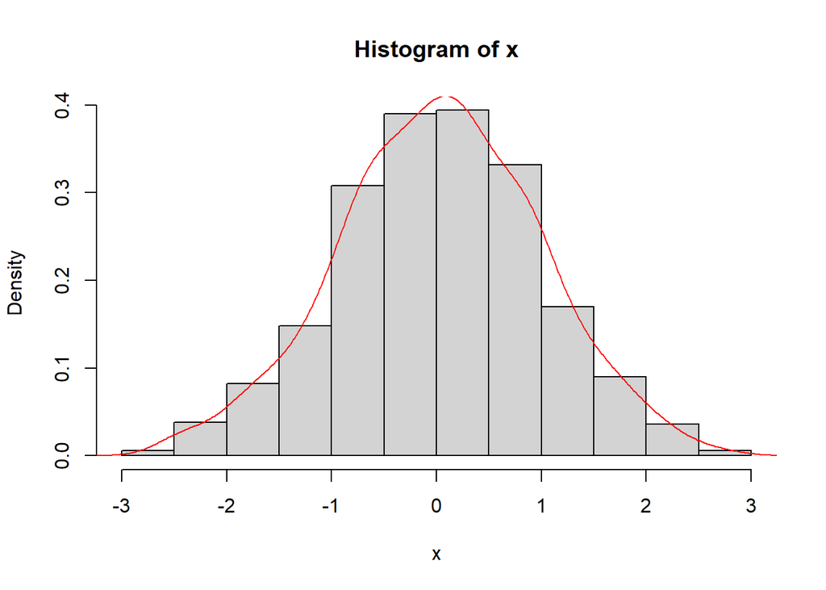

[output not shown]

[output not shown]

```r
x <- rnorm(1000, mean = 0, sd = 1) # sample from normal distribution
hist(x, prob = TRUE)
lines(density(x), col = "red")
```

##### (circular normal distribution (“von Mises Distribution”): $f(\theta | \mu, \kappa)$

$\kappa$ is the concentration parameter, ($\kappa > 0$, low values = random, high values = high concentration). Thus, $\frac{1}{kappa} \sim \sigma^2$.

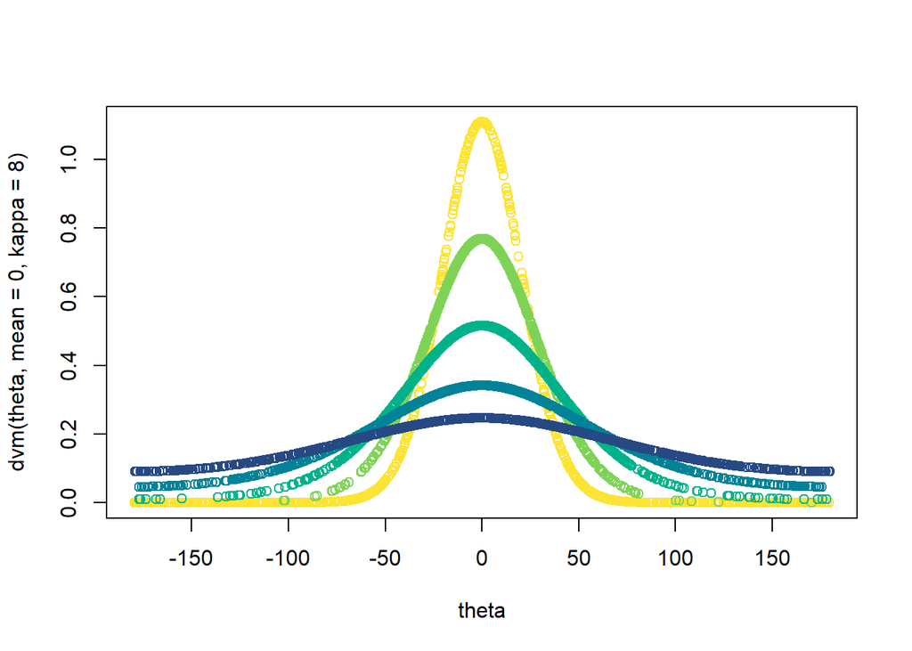

```r
cols = hcl.colors(6)
names(cols) <- as.character(c(.1, .5, 1, 2, 4, 8))

theta <- rvm(1000, mean = 180, kappa = 0.1)-180 # sample from von Mises distribution
plot(theta, dvm(theta, mean = 0, kappa = 8), type = "p", col = cols[as.character(8)])

for(k in c(4, 2, 1, 0.5)){
theta <- rvm(1000, mean = 180, kappa = k)-180 # sample from von Mises distribution
lines(theta, dvm(theta, mean = 0, kappa = k), type = "p", col = cols[as.character(k)])
}
```

Better as rose diagram:

```r
par(mfrow = c(2, 3))
for(k in c(0.1, .5, 1, 2, 4, 8)){
  rose(rvm(1000, mean = 0, kappa = k), main = paste("k =", k), col = cols[as.character(k)])
}
```

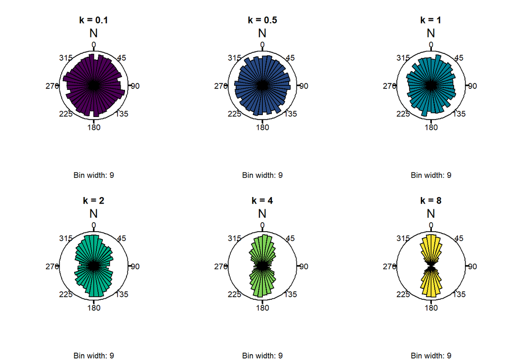

The parameter $\kappa$ is difficult to measure directly, but the concentration of the sample can be estimated from $\bar{R}$ (MLE). `tectonicr:::est.kappa()` estimates the parameter from the sample:

```r
tectonicr:::est.kappa(theta)
```

```
## [1] 0.3161602
```

#### Dispersion from an expected value

The “distance” measurement for two given angles $\theta$ and $\xi$ is the angular distance d:

$$d(\theta, \xi) = 1 - \cos{\theta -
\xi}$$
The dispersion of angles $\theta_1, ..., \theta_n$ about a given angle $\alpha$ is:

$$D(\alpha) = \frac{1}{n} \sum_{i=1}^{n}
d(\theta_i, \alpha)$$

```r
theta <- rvm(1000, mean = 45, kappa = 10) # sample from von Mises distribution
circular_dispersion(theta, 45)
```

```
## [1] 0.09708147
```

> Note that $D(\bar{\theta}) = \sigma^2$